# Q4_REGRESSION

Brendan Baker

2022-12-04

## Regression: What variables contribute most to predicting the popularity of a song?

After completing our exploratory data analysis (EDA) for the playlist, the next step was to fit a regression model. For our regression model, we hope to investigate the following data science question:

**Data science question:** What variables contribute most to predicting a songs popularity?

By using a regression model, we can determine which (if any) variables contribute to predicting a song’s popularity. This could be informative from a psychological perspective in that we can determine what features of a song contribute to it’s broad appeal. It could also inform musicians who hope to make popular music on what styles they should include to provide them with their best chance at reaching a broad audience. The first step in our analysis was to fit a full regression model with all variables. For our model, we began by including all continuous song variables. As the distribution of decades is highly skewed, it was removed from analysis. We will first only examine the full model with all variables and their interactions. A train-test split of 80-20 was used.

```r
# Load packages
library(tidyverse)
library(caret)
# Read in the data
songs <- read_csv('edyPlaylist.csv')

# Select only the features which we wish to include
song_vars <- songs %>%
  select(-c(...1, track.name, track.album.release_date, track.album.album_type, Playlist))

# Train test split
set.seed(0716)
# Do train test split (point i)
training.samples <- song_vars$track.popularity %>%
  createDataPartition(p = 0.8) # Do split
train.data  <- song_vars[training.samples$Resample1, ] # Train data
test.data <- song_vars[-training.samples$Resample1, ] # Test data
print(paste0("Training observations: ", dim(train.data)[1], " Test observations: ", dim(test.data)[1])) # Check dimensions
```

```
## [1] "Training observations: 782 Test observations: 194"
```

## Model building

### Model 1: Full regression without interactions

Before examining the full model, the data must be examined for the issue of multicollinearity.

```r
fit1 <- lm(track.popularity~(danceability + energy + loudness +
                 speechiness + acousticness + instrumentalness +
                 liveness + tempo + track.duration_ms + valence
                 ), data=train.data)
summary(fit1)
```

```
##
## Call:
## lm(formula = track.popularity ~ (danceability + energy + loudness +
##     speechiness + acousticness + instrumentalness + liveness +
##     tempo + track.duration_ms + valence), data = train.data)
##
## Residuals:
##     Min      1Q  Median      3Q     Max
## -64.466 -11.873   2.693  14.578  40.571
##
## Coefficients:
##                     Estimate Std. Error t value Pr(>|t|)
## (Intercept)        8.650e+01  7.567e+00  11.431  < 2e-16 ***
## danceability      -1.045e+00  5.325e+00  -0.196 0.844447
## energy            -1.693e+01  6.614e+00  -2.560 0.010671 *
## loudness           9.433e-01  2.569e-01   3.671 0.000258 ***
## speechiness        1.621e+00  9.839e+00   0.165 0.869188
## acousticness      -2.264e+01  3.635e+00  -6.228 7.78e-10 ***
## instrumentalness  -3.430e+00  3.112e+00  -1.102 0.270784
## liveness          -5.576e+00  4.422e+00  -1.261 0.207655
## tempo             -6.322e-02  2.474e-02  -2.555 0.010812 *
## track.duration_ms -8.361e-06  9.290e-06  -0.900 0.368397
## valence            8.297e+00  3.665e+00   2.264 0.023850 *
## ---
## Signif. codes:  0 '***' 0.001 '**' 0.01 '*' 0.05 '.' 0.1 ' ' 1
##
## Residual standard error: 18.81 on 771 degrees of freedom
## Multiple R-squared:  0.2332, Adjusted R-squared:  0.2232
## F-statistic: 23.45 on 10 and 771 DF,  p-value: < 2.2e-16
```

```r
car::vif(fit1)
```

```
##      danceability            energy          loudness       speechiness
##          2.085716          6.355999          4.407707          1.106689
##      acousticness  instrumentalness          liveness             tempo
##          3.704606          1.824318          1.109953          1.098494
## track.duration_ms           valence
##          1.095454          2.066618
```

In our initial regression model, the energy variable had a variance inflation factor (VIF) of 6.36, which is considered above the cutoff for a good model. As a result, we will dropped the energy variable from our regression.

### Model 2: No interactions, multicollinearity adjustment

```r
fit2 <- lm(track.popularity~(danceability + loudness +
                 speechiness + acousticness + instrumentalness +
                 liveness + tempo + track.duration_ms + valence
                 ), data=train.data)
summary(fit2)
```

```
##
## Call:
## lm(formula = track.popularity ~ (danceability + loudness + speechiness +
##     acousticness + instrumentalness + liveness + tempo + track.duration_ms +
##     valence), data = train.data)
##
## Residuals:
##     Min      1Q  Median      3Q     Max
## -64.462 -11.740   2.417  14.518  40.874
##
## Coefficients:
##                     Estimate Std. Error t value Pr(>|t|)
## (Intercept)        7.300e+01  5.445e+00  13.407  < 2e-16 ***
## danceability       1.030e+00  5.281e+00   0.195  0.84538
## loudness           5.431e-01  2.046e-01   2.654  0.00811 **
## speechiness       -1.993e-01  9.849e+00  -0.020  0.98386
## acousticness      -1.731e+01  2.992e+00  -5.787 1.04e-08 ***
## instrumentalness  -4.436e+00  3.099e+00  -1.432  0.15268
## liveness          -7.960e+00  4.338e+00  -1.835  0.06688 .
## tempo             -6.831e-02  2.475e-02  -2.760  0.00592 **
## track.duration_ms -1.001e-05  9.301e-06  -1.077  0.28199
## valence            5.197e+00  3.471e+00   1.497  0.13475
## ---
## Signif. codes:  0 '***' 0.001 '**' 0.01 '*' 0.05 '.' 0.1 ' ' 1
##
## Residual standard error: 18.87 on 772 degrees of freedom
## Multiple R-squared:  0.2267, Adjusted R-squared:  0.2177
## F-statistic: 25.14 on 9 and 772 DF,  p-value: < 2.2e-16
```

In our adjusted model, we found that the variables loudness, acousticness, and tempo were the significant predictors of popularity. The next step was to check run an interaction model.

### Model 3: Model with interactions

```r
fit3 <- lm(track.popularity~(danceability + loudness +
                 speechiness + acousticness + instrumentalness +
                 liveness + tempo + track.duration_ms + valence
                 )^2, data=train.data)
summary(fit3)
```

```
##
## Call:
## lm(formula = track.popularity ~ (danceability + loudness + speechiness +
##     acousticness + instrumentalness + liveness + tempo + track.duration_ms +
##     valence)^2, data = train.data)
##
## Residuals:
##     Min      1Q  Median      3Q     Max
## -63.181 -10.486   1.927  13.687  45.826
##
## Coefficients:
##                                      Estimate Std. Error t value Pr(>|t|)
## (Intercept)                         1.907e+01  2.731e+01   0.698  0.48528
## danceability                        6.985e+01  3.596e+01   1.942  0.05250 .
## loudness                           -1.079e+00  1.465e+00  -0.737  0.46151
## speechiness                         9.340e+01  9.691e+01   0.964  0.33552
## acousticness                        2.711e+01  2.093e+01   1.295  0.19562
## instrumentalness                   -4.482e+00  2.189e+01  -0.205  0.83783
## liveness                           -1.216e+01  3.504e+01  -0.347  0.72876
## tempo                              -6.075e-02  1.578e-01  -0.385  0.70040
## track.duration_ms                   1.261e-04  6.348e-05   1.987  0.04734 *
## valence                             9.023e+00  2.738e+01   0.330  0.74187
## danceability:loudness               1.215e+00  1.794e+00   0.677  0.49851
## danceability:speechiness            2.019e+01  7.933e+01   0.255  0.79916
## danceability:acousticness           1.078e+01  2.211e+01   0.488  0.62603
## danceability:instrumentalness      -3.057e+00  2.455e+01  -0.125  0.90093
## danceability:liveness               5.494e+01  3.659e+01   1.502  0.13363
## danceability:tempo                 -1.034e-01  1.862e-01  -0.555  0.57901
## danceability:track.duration_ms     -2.300e-04  7.460e-05  -3.084  0.00212 **
## danceability:valence               -1.263e+01  2.171e+01  -0.582  0.56086
## loudness:speechiness                2.672e+00  4.665e+00   0.573  0.56693
## loudness:acousticness               2.202e+00  7.132e-01   3.088  0.00209 **
## loudness:instrumentalness          -9.748e-01  6.553e-01  -1.488  0.13728
## loudness:liveness                   3.203e+00  1.675e+00   1.912  0.05627 .
## loudness:tempo                     -9.177e-03  7.454e-03  -1.231  0.21863
## loudness:track.duration_ms          2.559e-06  2.569e-06   0.996  0.31939
## loudness:valence                   -7.605e-01  1.184e+00  -0.643  0.52074
## speechiness:acousticness           -1.761e+00  5.664e+01  -0.031  0.97521
## speechiness:instrumentalness       -3.969e+01  1.167e+02  -0.340  0.73383
## speechiness:liveness               -1.094e+02  5.860e+01  -1.867  0.06227 .
```

[output cut: 9 more lines]

```
## instrumentalness:tempo              1.008e-01  1.103e-01   0.914  0.36090
## instrumentalness:track.duration_ms -1.132e-06  3.146e-05  -0.036  0.97130
## instrumentalness:valence           -4.057e+01  1.684e+01  -2.409  0.01624 *
## liveness:tempo                      1.909e-01  1.766e-01   1.081  0.28020
## liveness:track.duration_ms         -2.306e-05  5.036e-05  -0.458  0.64719
## liveness:valence                   -4.243e+01  2.560e+01  -1.657  0.09791 .
## tempo:track.duration_ms            -4.549e-08  3.109e-07  -0.146  0.88369
## tempo:valence                      -1.766e-02  1.227e-01  -0.144  0.88553
## track.duration_ms:valence           8.863e-05  5.239e-05   1.692  0.09110 .
## ---
## Signif. codes:  0 '***' 0.001 '**' 0.01 '*' 0.05 '.' 0.1 ' ' 1
##
## Residual standard error: 18.49 on 736 degrees of freedom
## Multiple R-squared:  0.2921, Adjusted R-squared:  0.2488
## F-statistic:  6.75 on 45 and 736 DF,  p-value: < 2.2e-16
```

In our interaction mode, the only significant single variable at the 95% confidence level was track duration. There were a few significant interaction terms, such as the interaction track duration:danceability, loudness:acousticness, acousticness:liveness, and instrumentalness:valence. For the final model, all terms that were not present in an interaction and the interaction terms that were not significant were dropped from the model. Due to the hierarchical principle in regression, any variables that are significant in an interaction must also be kept as a single variable term.

### Model 4: Model with interactions, trimmed.

```r
fit4 <- lm(track.popularity~(track.duration_ms + danceability + loudness + acousticness + valence + instrumentalness +
                               track.duration_ms*danceability + loudness*acousticness + acousticness*liveness + instrumentalness*valence
                 ), data=train.data)
summary(fit4)
```

```
##
## Call:
## lm(formula = track.popularity ~ (track.duration_ms + danceability +
##     loudness + acousticness + valence + instrumentalness + track.duration_ms *
##     danceability + loudness * acousticness + acousticness * liveness +
##     instrumentalness * valence), data = train.data)
##
## Residuals:
##     Min      1Q  Median      3Q     Max
## -62.699 -11.154   2.542  14.039  45.063
##
## Coefficients:
##                                  Estimate Std. Error t value Pr(>|t|)
## (Intercept)                     5.098e+01  7.053e+00   7.228 1.18e-12 ***
## track.duration_ms               7.896e-06  2.297e-05   0.344 0.731104
## danceability                    1.532e+01  1.302e+01   1.177 0.239745
## loudness                       -6.039e-01  3.626e-01  -1.666 0.096176 .
## acousticness                   -4.393e+00  5.244e+00  -0.838 0.402463
## valence                         7.085e+00  3.591e+00   1.973 0.048844 *
## instrumentalness                8.127e+00  4.369e+00   1.860 0.063245 .
## liveness                       -1.127e+01  6.051e+00  -1.862 0.062972 .
## track.duration_ms:danceability -4.961e-05  4.794e-05  -1.035 0.301106
## loudness:acousticness           1.710e+00  4.395e-01   3.892 0.000108 ***
## acousticness:liveness           1.048e+01  1.324e+01   0.791 0.429073
## valence:instrumentalness       -3.521e+01  1.008e+01  -3.494 0.000503 ***
## ---
## Signif. codes:  0 '***' 0.001 '**' 0.01 '*' 0.05 '.' 0.1 ' ' 1
##
## Residual standard error: 18.65 on 770 degrees of freedom
## Multiple R-squared:  0.2465, Adjusted R-squared:  0.2357
## F-statistic:  22.9 on 11 and 770 DF,  p-value: < 2.2e-16
```

## Model assessment

After model creation, the next step was to assess our model performance on the parameters of $R^2$, $RSE$, and $F$.

```r
# Make predictions
predictions1 <- fit1 %>% predict(test.data)
p1=data.frame(
  RMSE = RMSE(predictions1, test.data$track.popularity),
  R2 = R2(predictions1, test.data$track.popularity)
)

# Make predictions
predictions2 <- fit2 %>% predict(test.data)
p2=data.frame(
  RMSE = RMSE(predictions2, test.data$track.popularity),
  R2 = R2(predictions2, test.data$track.popularity)
)

# Make predictions
predictions3 <- fit3 %>% predict(test.data)
p3=data.frame(
  RMSE = RMSE(predictions3, test.data$track.popularity),
  R2 = R2(predictions3, test.data$track.popularity)
)

predictions4 <- fit4 %>% predict(test.data)
p4=data.frame(
  RMSE = RMSE(predictions4, test.data$track.popularity),
  R2 = R2(predictions4, test.data$track.popularity)
)

# Join the rows
all =rbind(p1,p2,p3,p4)

# Get all F-statistics
all=cbind(all, c(summary(fit1)$fstatistic[1],summary(fit2)$fstatistic[1],summary(fit3)$fstatistic[1],summary(fit4)$fstatistic[1]))

# Get all r-sqared statistics
all=cbind(all,c(summary(fit1)$adj.r.squared,summary(fit2)$adj.r.squared,summary(fit3)$adj.r.squared,summary(fit4)$adj.r.squared))

# Get all sigma values
all=cbind(all,c(summary(fit1)$sigma,summary(fit2)$sigma,summary(fit3)$sigma,summary(fit4)$sigma))

all = cbind(all, c('fit1','fit2','fit3','fit4'))
colnames(all)[c(3,4,5,6)]<-c("F stat","Adj R^2", "RSE","models")
all[,c(3,4,5,6)]
```

```
##      F stat   Adj R^2      RSE models
## 1 23.445599 0.2232380 18.80582   fit1
## 2 25.141965 0.2176526 18.87332   fit2
## 3  6.749562 0.2488437 18.49326   fit3
## 4 22.901322 0.2357482 18.65377   fit4
```

The results of our model make it difficult to decide what is best. The F statistic, which tells us how significant our model is, is strongest for the second model, which is the one without interactions. However, the second model also has the lowest $R^2$ value, which quantifies how well the response variable is predicted. The RSE or Residual Standard Error is lowest on model 3, which also has the lowest F statistic. The RSE is a measure of the residuals, or the distance from the predicted value. A lower RSE indicates a closer fit. To complete the rest of the analysis, and determine whether a linear model is suitable for the data at all, we will use model 4, which has a balance of all performance measures. Model 4 was our trimmed model that included interactions.

## Suitability for linear regression

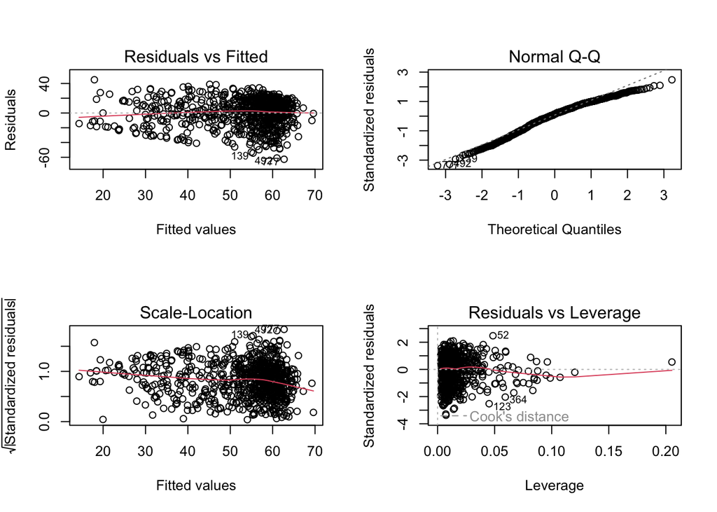

```r
par(mfrow=c(2,2))
plot(fit4)
```

## Conclusion

Overall, this question is not well-suited to regression and further analysis is needed to determine more conclusively what variables predict a song’s popularity.